# Assignment 2 - Looking at Differential Expression

Joelle Jee

## Load required packages

We will first load the required packages to clean, normalize and interpret the data.<sup>1-10</sup>

```r
knitr::opts_chunk$set(warning = FALSE)

if (!requireNamespace("BiocManager", quietly = TRUE)) {
  install.packages("BiocManager")
}

if (!requireNamespace("GEOquery", quietly = TRUE)) {
  BiocManager::install("GEOquery")
}

if (!requireNamespace("biomaRt", quietly = TRUE)) {
  BiocManager::install("biomaRt")
}

if (!requireNamespace("edgeR", quietly = TRUE)) {
  BiocManager::install("edgeR")
}

if (!requireNamespace("ComplexHeatmap")) {
  BiocManager::install("ComplexHeatmap")
}

if (!requireNamespace("circlize")) {
  BiocManager::install("circlize")
}

if (!requireNamespace("limma")) {
  BiocManager::install("limma")
}

if (!requireNamespace("enrichR")){
  devtools::install_github("wjawaid/enrichR")
}

if (!requireNamespace("kableExtra")){
  install.packages("kableExtra")
}
```

## Data Overview

Download the dataset (GEO accession: GSE121992) using package GEOquery.

```r
HbF_gse <- GEOquery::getGEO("GSE121992", GSEMatrix = FALSE)
HbF_gpl <- names(GEOquery::GPLList(HbF_gse))[1]
HbF_gpl_info <- GEOquery::Meta(GEOquery::getGEO(HbF_gpl))
```

### Platform Information

**Title of Platform:** Illumina HiSeq 2500 (Homo sapiens)  
**Submission Date:** Mar 14 2013  
**Last Update Date:** Mar 27 2019  
**Organism:** Homo sapiens  
**Number of GEO datasets using this study:** 6080  
**NUmber of GEO samples using this study:** 167630

## Load and visualize the cleaned, normalized data

### Loading Data from Assignment 1.

Load the cleaned, normalized gene counts data saved in the data folder from Assignment 1.

```r
normalized_count_data <- read.table(file = file.path("data", "GSE121992_finalized_normalized_counts.txt"),
                                    header = TRUE, sep = "\t",
                                    stringsAsFactors = FALSE,
                                    check.names = FALSE)

knitr::kable(normalized_count_data[1:5, 1:5], type = "html", caption = "Normalized Gene Counts")
```

Normalized Gene Counts

|  | sgSCR_pre_r1 | sgSCR_pre_r2 | sgSCR_pre_r3 | MBD2KO_pre_r1 | MBD2KO_pre_r2 |
| --- | --- | --- | --- | --- | --- |
| A2M | 1.758024 | 1.264504 | 1.4668128 | 1.5006191 | 0.9683397 |
| A2ML1 | 1.137545 | 1.115739 | 0.8381788 | 0.8687795 | 0.4841698 |
| A4GALT | 13.443712 | 17.182385 | 17.0778921 | 23.0621461 | 21.1098051 |
| AAAS | 8.996946 | 9.669740 | 9.2199663 | 8.7667747 | 12.2979140 |
| AACS | 54.498739 | 57.125851 | 60.7679598 | 27.9589032 | 31.5678737 |

### Visualization with a heatmap

A heatmap is a data graph that maps the measurements of many samples to a colour scale to allow better visualization of the overall trend of the data. With a heatmap, we can manipulate the format to highlight the themes in the data.

We will first visualize the above data using a heatmap.

To do so, we need to first create a numerical matrix representation of the data.

```r
heatmap_matrix <- normalized_count_data
rownames(heatmap_matrix) <- rownames(normalized_count_data)
colnames(heatmap_matrix) <- colnames(normalized_count_data)
```

Now we can create a heatmap.

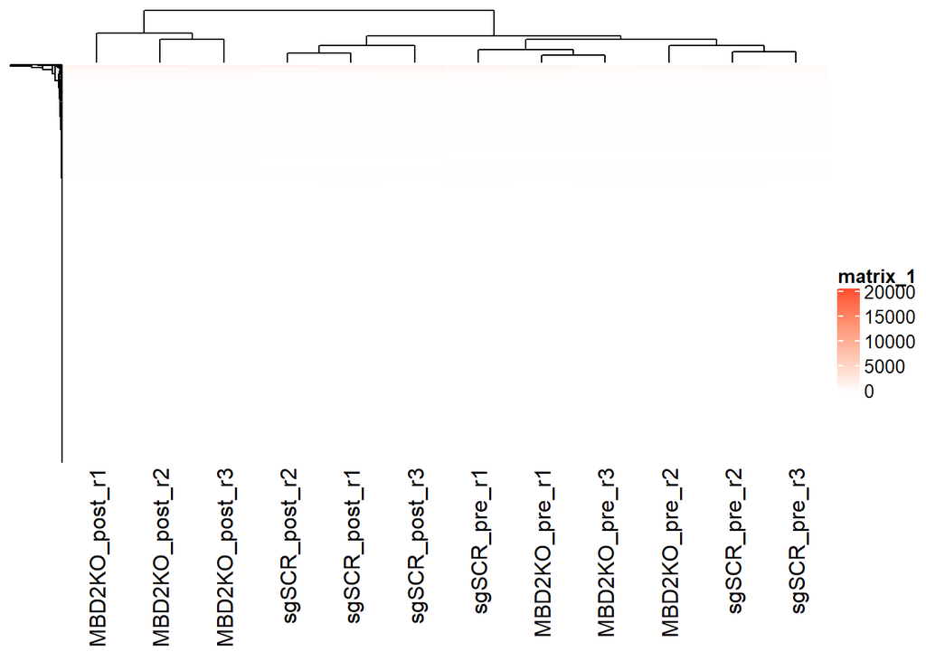

```r
# set color scale according to value
if(min(heatmap_matrix) == 0) {
  heatmap_col = circlize::colorRamp2(c(0, max(heatmap_matrix)), c("white", "red"))
} else {
  heatmap_col = circlize::colorRamp2(c(min(heatmap_matrix), 0, max(heatmap_matrix)), c("blue", "white", "red"))
}
# draw the heatmap
current_heatmap <- ComplexHeatmap::Heatmap(as.matrix(heatmap_matrix),
                                           show_row_dend = TRUE,
                                           show_column_dend = TRUE,
                                           col = heatmap_col,
                                           show_column_names = TRUE,
                                           show_row_names = FALSE,
                                           show_heatmap_legend = TRUE)


current_heatmap
```

As you can see, the above graph does not tell us any meaningful information. This is because the data is yet to be row-normalized, which is a method of scaling each row and centering them around the mean. The R function scale() takes each value and subtract the mean and divide by the standard deviaiton of the row to row normalize it. Let’s row-normalize the data and compare the heatmap drawn from it to the above heatmap.

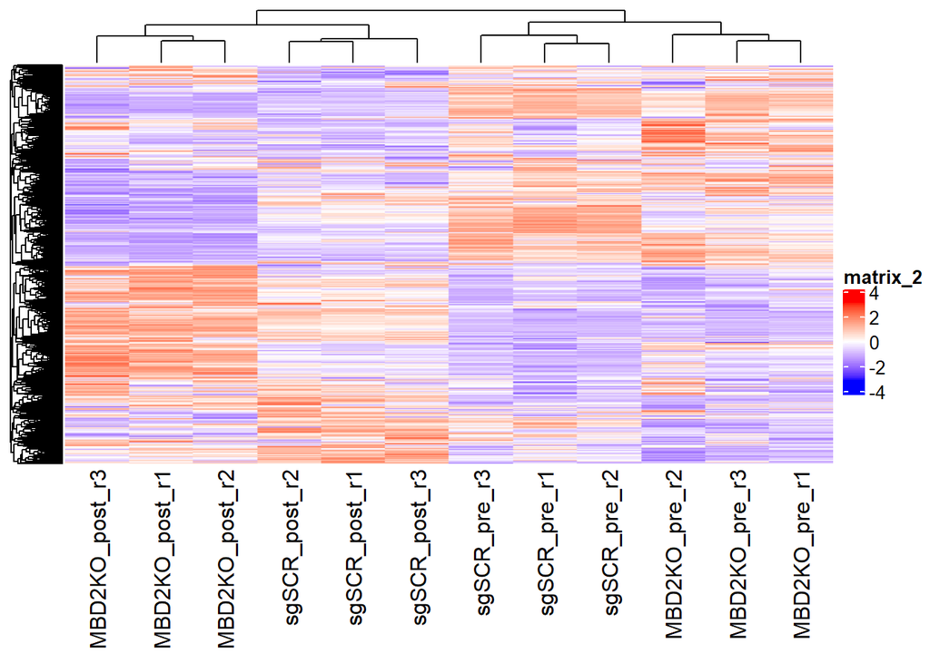

```r
# row normalize
heatmap_matrix <- t(scale(t(heatmap_matrix)))

# set color scale according to value
if (min(heatmap_matrix) == 0) {
  heatmap_col = circlize::colorRamp2(c(0, max(heatmap_matrix)), c("white", "red"))
} else {
  heatmap_col = circlize::colorRamp2(c(min(heatmap_matrix), 0, max(heatmap_matrix)), c("blue", "white", "red"))
}

# draw the heatmap
current_heatmap <- ComplexHeatmap::Heatmap(as.matrix(heatmap_matrix),
                                           show_row_dend = TRUE,
                                           show_column_dend = TRUE,
                                           col = heatmap_col,
                                           show_column_names = TRUE,
                                           show_row_names = FALSE,
                                           show_heatmap_legend = TRUE)

current_heatmap
```

A row-normalized heatmap as above depicts meaningful information; more blue the color is, more downregulated the gene is in the sample, and more red the color is, more upregulated the gene is in the sample. Each column represents each sample, and we can see from the heatmap genes in the same samples tend to cluster in values. For each cell type (e.g. MBD2KO_post), we can see that the reps (e.g. r3) have similar coloring on the heatmap, which means that same genes tend to be upregulated/downregulated compared to the overall mean.

## Defining differential expression with Limma

We will be using linear models of microarray (Limma), which uses linear models to define/explain differential expression.  
Later in this same assignment, we will use Quali Likelihood

### Group and Cluster

A multidimensional scaling (MDS) plot is allows visualization of similarity between each sample in a dataset. Using the limma package, let’s see how our samples are clustering with MDSPlot.

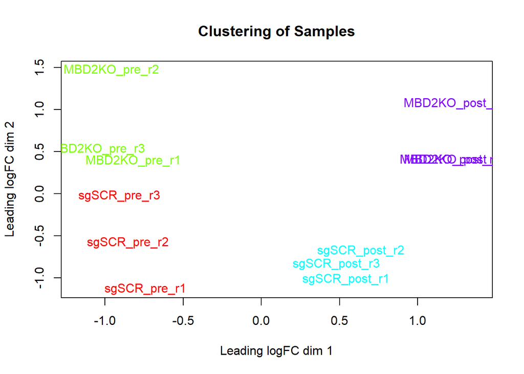

```r
# set color scale
sample_col <- rainbow(4)
sample_col <- unlist(lapply(sample_col,
                            FUN = function(x){rep(x, 3)}))
# draw the MDSPlot to see the clustering by sample
limma::plotMDS(heatmap_matrix,
               col = sample_col,
               main = "Clustering of Samples")
```

As seen from the heatmap before, we can see that the cell types tend to cluster to themselves.

Now we will define the groups and store it in variable samples.

```r
# parse the column names to replication number rep
# and cell type (e.g. sgSCR_pre_r1 to sgSCR_pre and r1)
samples <- data.frame(
  lapply(colnames(normalized_count_data),
         FUN=function(x){
           x_split <- unlist(strsplit(x, split = "_"))
           rep <- x_split[3]
           cell_type <- paste(x_split[c(1, 2)], collapse = "_")
           return (c(rep, cell_type))}))

# set column and row names
colnames(samples) <- colnames(normalized_count_data)
rownames(samples) <- c("replication","cell_type")

# Group and view samples
samples <- data.frame(t(samples))
knitr::kable(samples[1:5,], type = "html", caption = "Samples")
```

Samples

|  | replication | cell_type |
| --- | --- | --- |
| sgSCR_pre_r1 | r1 | sgSCR_pre |
| sgSCR_pre_r2 | r2 | sgSCR_pre |
| sgSCR_pre_r3 | r3 | sgSCR_pre |
| MBD2KO_pre_r1 | r1 | MBD2KO_pre |
| MBD2KO_pre_r2 | r2 | MBD2KO_pre |

### Create ExpressionSet

Let’s use an R function, model.matrix, to create a design matrix.

```r
# create a design matrix for our dataset
model_design <- model.matrix(~ samples$cell_type)
knitr::kable(model_design, type = "html", caption = "Model Design Matrix")
```

Model Design Matrix

[output not shown]

Now create our data matrix usign ExpressionSet

```r
expressionMatrix <- as.matrix(normalized_count_data)
rownames(expressionMatrix) <- rownames(normalized_count_data)
colnames(expressionMatrix) <- colnames(normalized_count_data)

# create an ExpressionSet object of our dataset
minimalSet <- Biobase::ExpressionSet(assayData=expressionMatrix)
```

Fit our data to the above model

```r
fit <- limma::lmFit(minimalSet, model_design)
```

Apply empirical Bayes (function eBayes from package limma) and compute the differential expression for the above model. This essentially computes the probability of any gene being differentially expressed given its constrasts.

```r
fit2 <- limma::eBayes(fit,trend=TRUE)
# extract the top-ranked genes from the linear model fit (fit2)
output_hits <- limma::topTable(fit2,
                               coef=c(2:ncol(model_design)),
                               adjust.method = "BH",
                               number = nrow(expressionMatrix))

#sort by pvalue
output_hits <- output_hits[order(output_hits$P.Value),]

knitr::kable(output_hits[1:10,], type = "html", caption = "Top Hits")
```

Top Hits

|  | samples.cell_typeMBD2KO_pre | samples.cell_typesgSCR_post | samples.cell_typesgSCR_pre | AveExpr | F | P.Value | adj.P.Val |
| --- | --- | --- | --- | --- | --- | --- | --- |
| CPEB4 | -264.15710 | -274.83228 | -301.84261 | 127.50424 | 3660.684 | 0 | 0 |
| DOCK2 | 146.63708 | 49.39042 | 253.84792 | 123.86734 | 2473.479 | 0 | 0 |
| ZNF521 | 34.94387 | 29.61917 | 192.89599 | 67.10143 | 2221.236 | 0 | 0 |
| NUDT4 | -503.65261 | -415.50740 | -521.04469 | 230.40779 | 1612.900 | 0 | 0 |
| CA8 | -349.75813 | -18.25207 | -376.80420 | 337.52430 | 1592.194 | 0 | 0 |
| GSTM3 | 233.93283 | 51.81708 | 280.81196 | 174.16501 | 1508.807 | 0 | 0 |
| MYO18B | -45.05828 | -53.57384 | -53.96233 | 15.84819 | 1345.927 | 0 | 0 |
| LAPTM4B | 226.56313 | 30.57931 | 334.41930 | 192.15660 | 1333.827 | 0 | 0 |
| FBN1 | 74.34136 | 16.60553 | 208.77350 | 92.21256 | 1319.416 | 0 | 0 |
| DDI2 | -287.12210 | -287.02957 | -342.89637 | 243.15889 | 1285.049 | 0 | 0 |

### Genes that pass the threshold

Let’s see how many genes pass the threshold p-values of 0.05. The threshold of 0.05 is chosen as it is the most widely accept p-value as it means that there are less than 5% chance of a positive result from mere chance. I will be using this threshold throughout this assignment.

```r
length(which(output_hits$P.Value < 0.05))
```

```
## [1] 10573
```

… and genes that pass correction.

```r
length(which(output_hits$adj.P.Val < 0.05))
```

```
## [1] 10192
```

## Multiple Hypothesis Correction

We need to correct the p-values using a multiple hypothesis correction method because we need to account for the fact the likelihood of positive result is enhanced by number or replications of each sample. For example, since we have 3 replications of each cell type, the likelihood of positive outcome in at least of the replications is increased by x3. To control for family-wise error rate or for false discovery rate, we will use the BH (Benjamini-Hochberg) method as it is a very popular method for controlling the false discovery rate in the field of science (and often the default method for many functions in R).  
Also we will account for replication variability as well as samples in our model design.

```r
model_design_pat <- model.matrix( ~ samples$replication + samples$cell_type)
knitr::kable(model_design_pat, typr = "html", caption = "Corrected Model Design")
```

Corrected Model Design

[output not shown]

Now fit our data to the above model

```r
fit_pat <- limma::lmFit(minimalSet, model_design_pat)
```

```r
fit2_pat <- limma::eBayes(fit_pat,trend=TRUE)
output_hits_pat <- limma::topTable(fit2_pat,
                                   coef=c(2:ncol(model_design_pat)),
                                   adjust.method = "BH",
                                   number = nrow(expressionMatrix))

#sort by pvalue
output_hits_pat <- output_hits_pat[order(output_hits_pat$P.Value),]

knitr::kable(output_hits_pat[1:10,], type = "html", caption = "Corrected Top Hits")
```

Corrected Top Hits

|  | samples.replicationr2 | samples.replicationr3 | samples.cell_typeMBD2KO_pre | samples.cell_typesgSCR_post | samples.cell_typesgSCR_pre | AveExpr | F | P.Value | adj.P.Val |
| --- | --- | --- | --- | --- | --- | --- | --- | --- | --- |
| CPEB4 | -4.2461200 | 0.0829275 | -264.15710 | -274.83228 | -301.8426 | 127.50424 | 2475.1221 | 0 | 0 |
| ZNF521 | -1.2228050 | 2.5820038 | 34.94387 | 29.61917 | 192.8960 | 67.10143 | 1477.2282 | 0 | 0 |
| VIM | -28.5232900 | 25.7875200 | 402.23747 | 114.72954 | 1158.3801 | 471.56201 | 1325.6773 | 0 | 0 |
| DOCK2 | -1.8021293 | -0.5383392 | 146.63708 | 49.39042 | 253.8479 | 123.86734 | 1321.5893 | 0 | 0 |
| NUDT4 | -2.9730650 | 9.9376025 | -503.65261 | -415.50740 | -521.0447 | 230.40779 | 1160.5921 | 0 | 0 |
| GSTM3 | -8.0790950 | -4.2512925 | 233.93283 | 51.81708 | 280.8120 | 174.16501 | 1099.2701 | 0 | 0 |
| CA8 | -9.7303500 | -4.2576000 | -349.75813 | -18.25207 | -376.8042 | 337.52430 | 1045.6201 | 0 | 0 |
| FBN1 | -4.5662475 | 1.1199475 | 74.34136 | 16.60553 | 208.7735 | 92.21256 | 957.0299 | 0 | 0 |
| DDI2 | -7.8948500 | -5.4530750 | -287.12210 | -287.02957 | -342.8964 | 243.15889 | 831.3054 | 0 | 0 |
| IQGAP1 | -0.1592975 | 6.8349950 | 186.55556 | 47.66414 | 256.0412 | 155.51242 | 767.1349 | 0 | 0 |

Let’s now see if the number of genes that pass the threshold p-value has changed.

```r
length(which(output_hits_pat$P.Value < 0.05))
```

```
## [1] 10404
```

… and geens that pass correction

```r
length(which(output_hits_pat$adj.P.Val < 0.05))
```

```
## [1] 9952
```

### Comparing the results from two different models

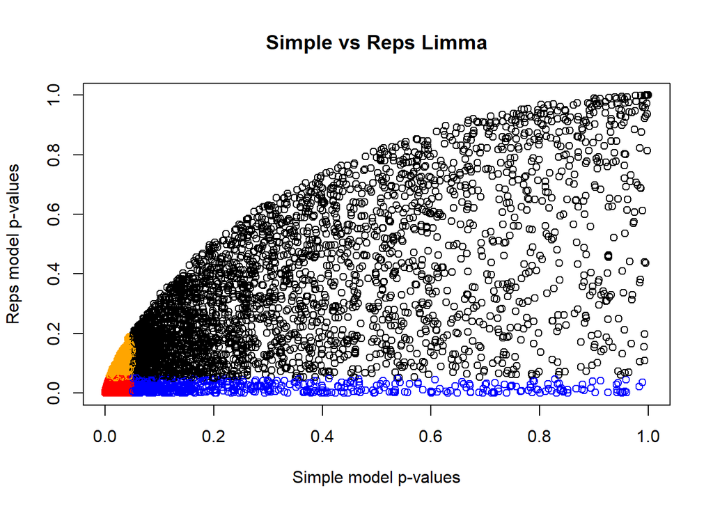

```r
# original dataset
simple_model_pvalues <- data.frame(hgnc = rownames(output_hits),
                                   simple_pvalue=output_hits$P.Value)
# corrected for and reps accounted for
pat_model_pvalues <-  data.frame(hgnc = rownames(output_hits_pat),
                                 reps_pvalue = output_hits_pat$P.Value)
# merge the results of two models
two_models_pvalues <- merge(simple_model_pvalues,
                            pat_model_pvalues,by.x=1,by.y=1)

two_models_pvalues$colour <- "black"
# color the original dataset points orange
two_models_pvalues$colour[two_models_pvalues$simple_pvalue<0.05] <- "orange"
# color the corrected dataset point blue
two_models_pvalues$colour[two_models_pvalues$reps_pvalue<0.05] <- "blue"
# overlapping dataset points are colored red
two_models_pvalues$colour[two_models_pvalues$simple_pvalue<0.05 & two_models_pvalues$reps_pvalue<0.05] <- "red"

# let's pot to see the difference
plot(two_models_pvalues$simple_pvalue,two_models_pvalues$reps_pvalue,
     col = two_models_pvalues$colour,
     xlab = "Simple model p-values",
     ylab ="Reps model p-values",
     main="Simple vs Reps Limma")
```

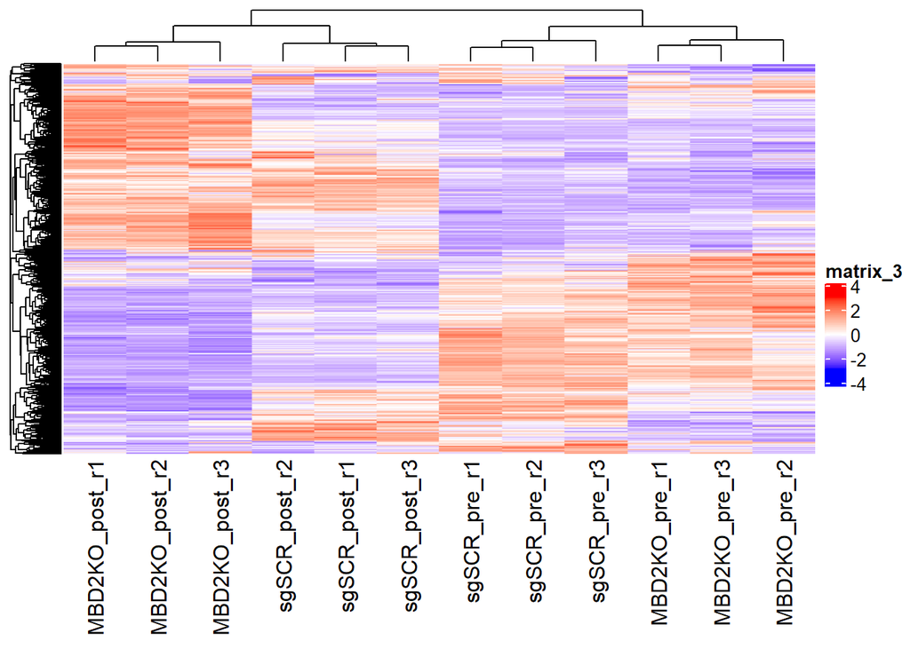

```r
# Get the significant data points
top_hits <- rownames(output_hits_pat)[output_hits_pat$P.Value<0.05]
# extract the significant dat points and row normalize
heatmap_matrix_tophits <- t(
  scale(t(heatmap_matrix[
    which(rownames(heatmap_matrix) %in% top_hits),])))

# set the colour scale
if(min(heatmap_matrix_tophits) == 0){
    heatmap_col = circlize::colorRamp2(c( 0, max(heatmap_matrix_tophits)),
                             c( "white", "red"))
  } else {
    heatmap_col = circlize::colorRamp2(c(min(heatmap_matrix_tophits), 0, max(heatmap_matrix_tophits)), c("blue", "white", "red"))
  }

# draw the heatmap
current_heatmap <- ComplexHeatmap::Heatmap(as.matrix(heatmap_matrix_tophits),
                                           cluster_rows = TRUE,
                                           cluster_columns = TRUE,
                                           show_row_dend = TRUE,
                                           show_column_dend = TRUE,
                                           col=heatmap_col,
                                           show_column_names = TRUE,
                                           show_row_names = FALSE,
                                           show_heatmap_legend = TRUE
)

current_heatmap
```

Let’s group the columns by cell type and have argument cluster_columns off, and see the difference.

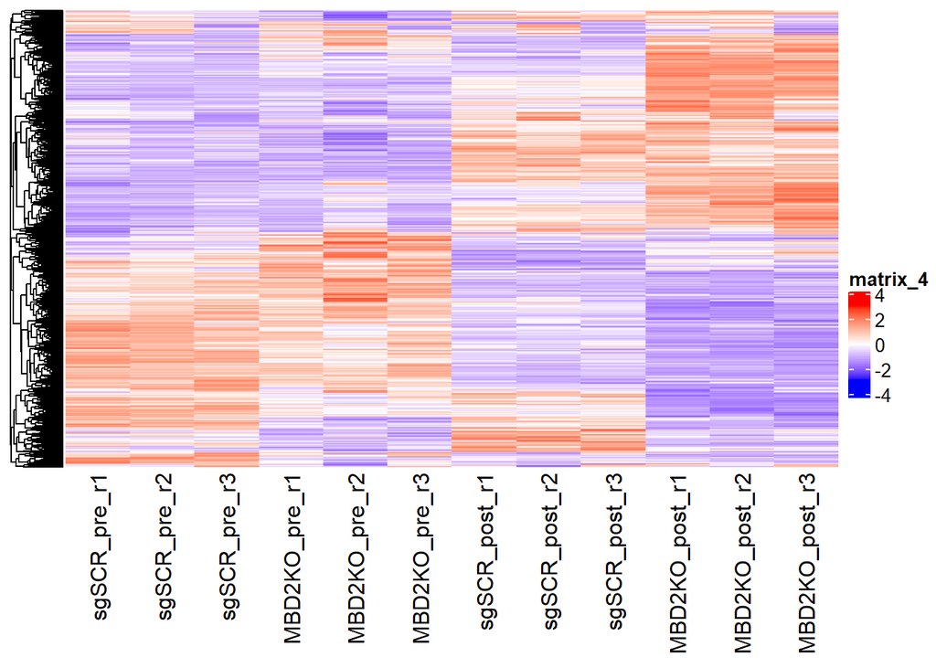

```r
heatmap_matrix_tophits<- heatmap_matrix_tophits[,
                                                c(
                                                  grep(colnames(heatmap_matrix_tophits),pattern = "sgSCR_pre"),
                                                  grep(colnames(heatmap_matrix_tophits),pattern = "MBD2KO_pre"),
                                                  grep(colnames(heatmap_matrix_tophits),pattern = "sgSCR_post"),
                                                  grep(colnames(heatmap_matrix_tophits),pattern = "MBD2KO_post")
                                                )]
if(min(heatmap_matrix_tophits) == 0){
  heatmap_col = circlize::colorRamp2(c( 0, max(heatmap_matrix_tophits)),
                                     c( "white", "red"))
} else {
  heatmap_col = circlize::colorRamp2(c(min(heatmap_matrix_tophits), 0, max(heatmap_matrix_tophits)), c("blue", "white", "red"))
}
current_heatmap <- ComplexHeatmap::Heatmap(as.matrix(heatmap_matrix_tophits),
                                           cluster_rows = TRUE,
                                           cluster_columns = FALSE,
                                           show_row_dend = TRUE,
                                           show_column_dend = TRUE,
                                           col=heatmap_col,
                                           show_column_names = TRUE,
                                           show_row_names = FALSE,
                                           show_heatmap_legend = TRUE
)

current_heatmap
```

You can see that samples show a little bit stronger clustering. The colors are a little bit more intensified in the sample groups.  
We’ll get a slightly cleaner picture by rendering just the genes that are in the top hits with p-value < 0.01 (before we use the 0.05 cut-off).

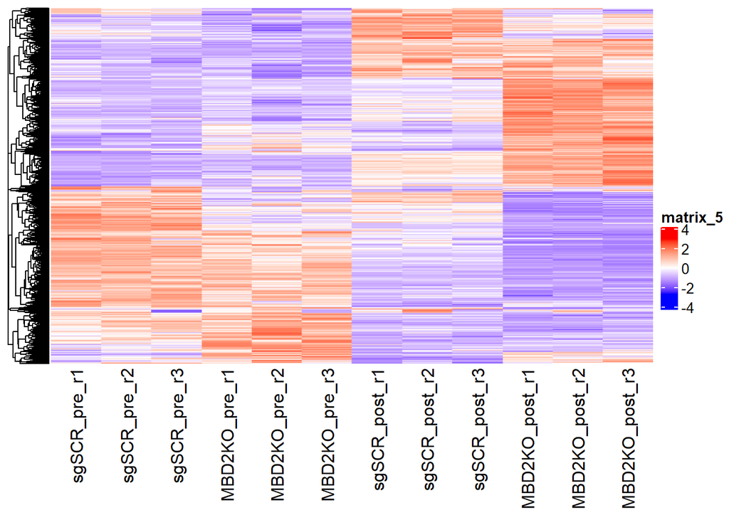

```r
# get the top hits genes
top_hits <- rownames(output_hits_pat)[output_hits_pat$P.Value<0.01]
# extract the top this genes and row normalize
heatmap_matrix_tophits <- t(
  scale(t(heatmap_matrix[which(rownames(heatmap_matrix) %in% top_hits),])))
# group by samples
heatmap_matrix_tophits<- heatmap_matrix_tophits[,
                                                c(
                                                  grep(colnames(heatmap_matrix_tophits),pattern = "sgSCR_pre"),
                                                  grep(colnames(heatmap_matrix_tophits),pattern = "MBD2KO_pre"),
                                                  grep(colnames(heatmap_matrix_tophits),pattern = "sgSCR_post"),
                                                  grep(colnames(heatmap_matrix_tophits),pattern = "MBD2KO_post")
                                                )]
# set the color scale
if(min(heatmap_matrix_tophits) == 0){
  heatmap_col = circlize::colorRamp2(c( 0, max(heatmap_matrix_tophits)),
                                     c( "white", "red"))
} else {
  heatmap_col = circlize::colorRamp2(c(min(heatmap_matrix_tophits), 0, max(heatmap_matrix_tophits)), c("blue", "white", "red"))
}

# draw the heatmap
current_heatmap <- ComplexHeatmap::Heatmap(as.matrix(heatmap_matrix_tophits),
                                           cluster_rows = TRUE,  show_row_dend = TRUE,
                                           cluster_columns = FALSE,show_column_dend = FALSE,
                                           col=heatmap_col,show_column_names = TRUE,
                                           show_row_names = FALSE,show_heatmap_legend = TRUE)

current_heatmap
```

You can see that the colors have intensified even more than before; this is because we are using only the genes that have extremely low p-values. The clustering of the cell types is quite obvious to see.

## Calculating differential expression with Quali likelihood model

Set up edgeR objects and use the Quali likelihood model to calculate differential expression.

```r
# first need to read filtered_data_matrix from Assignment 1
filtered_data_matrix <- read.csv(file = file.path("data", "filtered_data_matrix.csv"),
                                   header = TRUE, sep = ",",
                                   stringsAsFactors = FALSE,
                                   check.names = FALSE,
                                   row.names = 1)
# set up our edgeR objects
d = edgeR::DGEList(counts=filtered_data_matrix, group=samples$cell_type)

# estimate Dispersion - our model design.
d <- edgeR::estimateDisp(d, model_design_pat)

# and fit the model
fit <- edgeR::glmQLFit(d, model_design_pat)

qlf.pos_vs_neg <- edgeR::glmQLFTest(fit, coef=c('samples$cell_typesgSCR_pre',
                                                'samples$cell_typeMBD2KO_pre',
                                                'samples$cell_typesgSCR_post'))

# extract the most differentially expressed genes
knitr::kable(edgeR::topTags(qlf.pos_vs_neg), type = "html", caption = "Top Hits")
```

Top Hits

|  | logFC.samples.cell_typesgSCR_pre | logFC.samples.cell_typeMBD2KO_pre | logFC.samples.cell_typesgSCR_post | logCPM | F | PValue | FDR |
| --- | --- | --- | --- | --- | --- | --- | --- |
| H1-0 | -8.888553 | -4.807730 | -2.198575 | 6.227585 | 2009.725 | 0 | 0 |
| HPGD | 6.147452 | 3.463519 | 2.719917 | 7.616119 | 1840.786 | 0 | 0 |
| VIM | 4.713064 | 3.286962 | 1.816788 | 8.932626 | 1705.470 | 0 | 0 |
| AHNAK | 4.918749 | 3.986172 | 2.656137 | 9.884336 | 1701.223 | 0 | 0 |
| TRIM10 | -7.754869 | -2.138331 | -4.620028 | 6.317904 | 1598.063 | 0 | 0 |
| RHEX | 6.952406 | 5.871280 | 3.738730 | 5.913090 | 1289.171 | 0 | 0 |
| GSTM3 | 3.452289 | 3.212464 | 1.523140 | 7.496596 | 1191.233 | 0 | 0 |
| CPEB4 | -3.052737 | -2.022073 | -2.280067 | 6.907860 | 1151.034 | 0 | 0 |
| SLC4A1 | -8.615126 | -3.036945 | -4.178777 | 8.258044 | 1135.755 | 0 | 0 |
| DOCK2 | 4.728975 | 3.975398 | 2.568262 | 7.014086 | 1129.148 | 0 | 0 |

[output not shown]

[output not shown]

[output not shown]

See the results sorted by the p-value.

```r
qlf_output_hits <- edgeR::topTags(qlf.pos_vs_neg,sort.by = "PValue",
                           n = nrow(normalized_count_data))

knitr::kable(qlf_output_hits[1:10, ], type = "html", caption = "Top Hits by p-value")
```

Top Hits by p-value

|  | logFC.samples.cell_typesgSCR_pre | logFC.samples.cell_typeMBD2KO_pre | logFC.samples.cell_typesgSCR_post | logCPM | F | PValue | FDR |
| --- | --- | --- | --- | --- | --- | --- | --- |
| H1-0 | -8.888553 | -4.807730 | -2.198575 | 6.227585 | 2009.725 | 0 | 0 |
| HPGD | 6.147452 | 3.463519 | 2.719917 | 7.616119 | 1840.786 | 0 | 0 |
| VIM | 4.713064 | 3.286962 | 1.816788 | 8.932626 | 1705.470 | 0 | 0 |
| AHNAK | 4.918749 | 3.986172 | 2.656137 | 9.884336 | 1701.223 | 0 | 0 |
| TRIM10 | -7.754869 | -2.138331 | -4.620028 | 6.317904 | 1598.063 | 0 | 0 |
| RHEX | 6.952406 | 5.871280 | 3.738730 | 5.913090 | 1289.171 | 0 | 0 |
| GSTM3 | 3.452289 | 3.212464 | 1.523140 | 7.496596 | 1191.233 | 0 | 0 |
| CPEB4 | -3.052737 | -2.022073 | -2.280067 | 6.907860 | 1151.034 | 0 | 0 |
| SLC4A1 | -8.615126 | -3.036945 | -4.178777 | 8.258044 | 1135.755 | 0 | 0 |
| DOCK2 | 4.728975 | 3.975398 | 2.568262 | 7.014086 | 1129.148 | 0 | 0 |

[output not shown]

[output not shown]

[output not shown]

### Genes passing the threshold

How many gene pass the threshold p-value < 0.05?

```r
length(which(qlf_output_hits$table$PValue < 0.05))
```

```
## [1] 11383
```

How many genes pass correction?

```r
length(which(qlf_output_hits$table$FDR < 0.05))
```

```
## [1] 11147
```

### Compare the results from Limma and Quali

We compare the Limma vs Quali likelihood results with a plot.

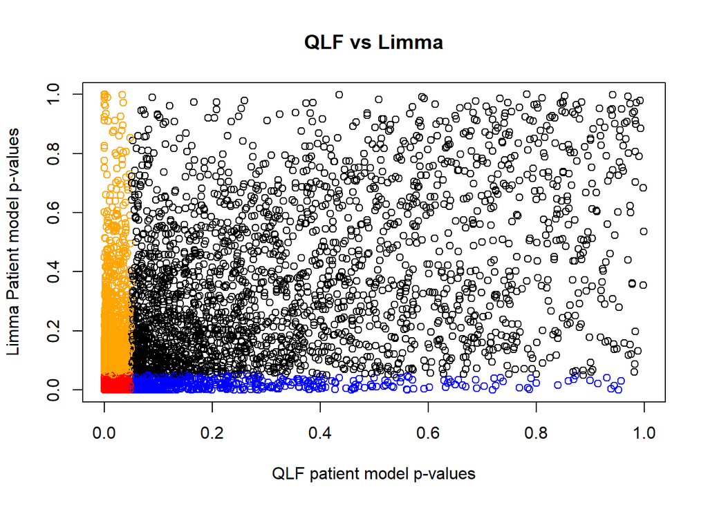

```r
# Quali likelihood results
qlf_pat_model_pvalues <- data.frame(
          hgnc = rownames(qlf_output_hits$table),
          qlf_patient_pvalue=qlf_output_hits$table$PValue)
# Limma results
limma_pat_model_pvalues <-  data.frame(
          hgnc = rownames(output_hits_pat),
          limma_patient_pvalue = output_hits_pat$P.Value)
# merge the two results
two_models_pvalues <- merge(qlf_pat_model_pvalues,
                            limma_pat_model_pvalues,
                            by.x=1,by.y=1)

# overlap the two results using different colours
two_models_pvalues$colour <- "black"
two_models_pvalues$colour[two_models_pvalues$qlf_patient_pvalue<0.05] <- "orange"
two_models_pvalues$colour[two_models_pvalues$limma_patient_pvalue<0.05] <- "blue"
two_models_pvalues$colour[two_models_pvalues$qlf_patient_pvalue<0.05 & two_models_pvalues$limma_patient_pvalue<0.05] <- "red"

# draw the results in as a plot
plot(two_models_pvalues$qlf_patient_pvalue,
     two_models_pvalues$limma_patient_pvalue,
     col = two_models_pvalues$colour,
     xlab = "QLF patient model p-values",
     ylab ="Limma Patient model p-values",
     main="QLF vs Limma")
```

Blue: Limma method result  
Orange: Quali likelihood result  
Red: Overlap of Limma and Quali likelihood results  
Black: all other data points  
It seems that both analyses have similar distribution of results.

### Looking at genes of interest.

We will highlight our genes of interest. I have selected two groups of genes of interest: one for regulation of HbF and the other for differentiation of erythroid cells.<sup>12</sup>

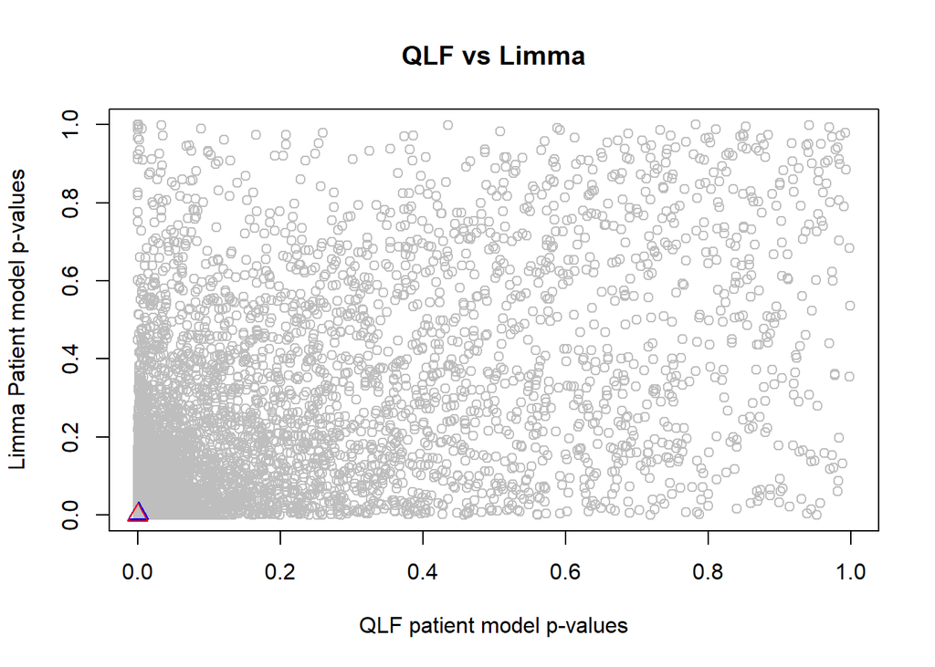

```r
HbF_reg <- c("BCL11A", "MYB")
diff_reg <- c("SPI1", "ALAS1", "ALAS2")

two_models_pvalues$colour <- "grey"
# give different colour sfor each genes of interest
two_models_pvalues$colour[two_models_pvalues$hgnc %in% HbF_reg] <- "red"
two_models_pvalues$colour[two_models_pvalues$hgnc %in% diff_reg] <- "blue"

# now plot
plot(two_models_pvalues$qlf_patient_pvalue,
     two_models_pvalues$limma_patient_pvalue,
     col = two_models_pvalues$colour,
     xlab = "QLF patient model p-values",
     ylab ="Limma Patient model p-values",
     main="QLF vs Limma")

# draw the points that correspond to the gene of interest
points(two_models_pvalues[
  two_models_pvalues$hgnc %in% diff_reg,2:3],
       pch=24,  col="blue", cex=1.5)
points(two_models_pvalues[
  two_models_pvalues$hgnc %in% HbF_reg,2:3],
       pch=24,  col="red", cex=1.5)
```

The little triangles (red = HbF tags, blue = differentiation tags) in the bottom left corner are the genes of interest. As you can see they have a very low p-value, which means that they were significantly differntially expressed in the dataset as we expected.

### Visualization with a heatmap

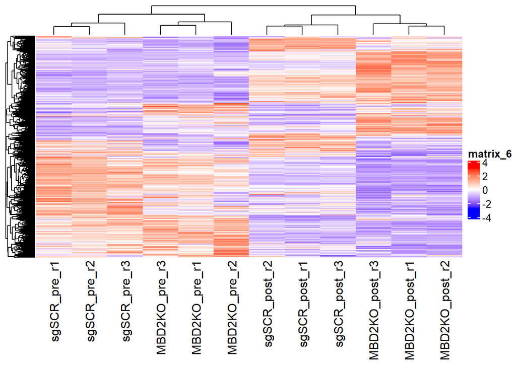

```r
# top hits from Quali likelihood results
top_hits <- rownames(qlf_output_hits$table)[output_hits_pat$P.Value<0.05]
# row normalize only the genes in the top hits
heatmap_matrix_tophits <- t(
  scale(t(heatmap_matrix[which(rownames(heatmap_matrix) %in% top_hits),])))
# set color scale
if(min(heatmap_matrix_tophits) == 0){
  heatmap_col = circlize::colorRamp2(c( 0, max(heatmap_matrix_tophits)),
                                     c( "white", "red"))
  } else {
    heatmap_col = circlize::colorRamp2(c(min(heatmap_matrix_tophits), 0, max(heatmap_matrix_tophits)), c("blue", "white", "red"))
  }

current_heatmap <- ComplexHeatmap::Heatmap(as.matrix(heatmap_matrix_tophits),
                                           cluster_rows = TRUE,
                                           cluster_columns = TRUE,
                                           show_row_dend = TRUE,
                                           show_column_dend = TRUE,
                                           col=heatmap_col,
                                           show_column_names = TRUE,
                                           show_row_names = FALSE,
                                           show_heatmap_legend = TRUE
)
current_heatmap
```

Sort the columns by cell type and turn cluster_columsn argument to FALSE.

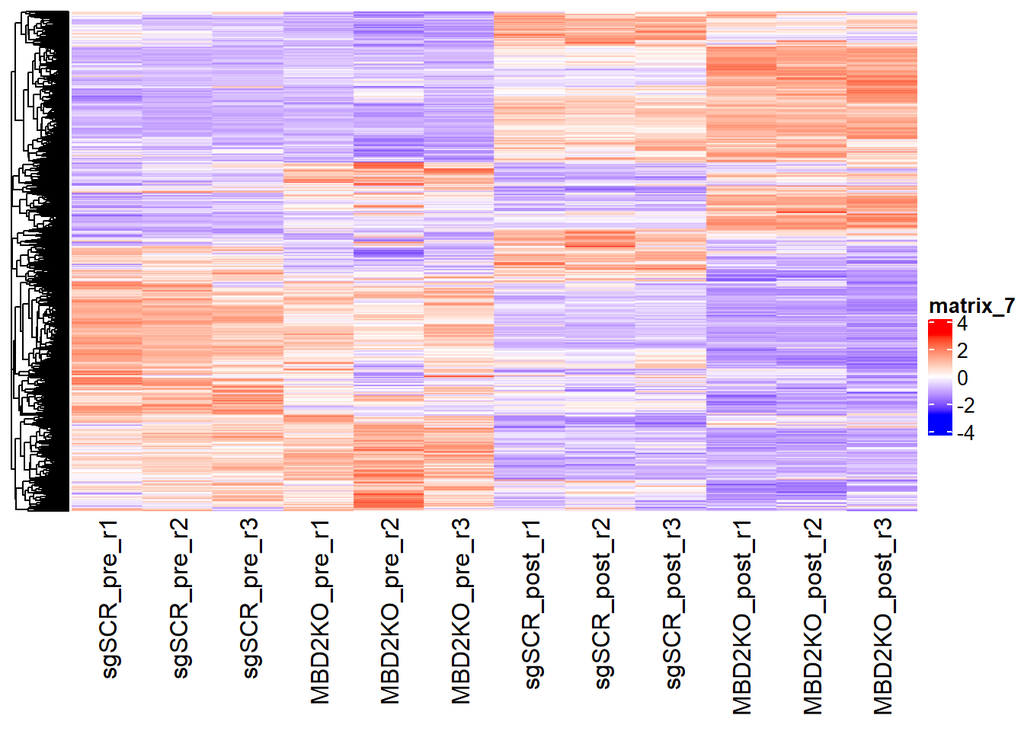

```r
# top hits from the Quali likelihood results
top_hits <- rownames(qlf_output_hits$table)[output_hits_pat$P.Value<0.05]
# row normalize to include just the top hits
heatmap_matrix_tophits <- t(
  scale(t(heatmap_matrix[which(rownames(heatmap_matrix) %in% top_hits),])))
# group by the cell type
heatmap_matrix_tophits<- heatmap_matrix_tophits[,
                                                c(grep(colnames(heatmap_matrix_tophits),pattern = "sgSCR_pre"),
                                                  grep(colnames(heatmap_matrix_tophits),pattern = "MBD2KO_pre"),
                                                  grep(colnames(heatmap_matrix_tophits),pattern = "sgSCR_post"),
                                                  grep(colnames(heatmap_matrix_tophits),pattern = "MBD2KO_post")
                                                )]
# set color scale
if(min(heatmap_matrix_tophits) == 0){
  heatmap_col = circlize::colorRamp2(c( 0, max(heatmap_matrix_tophits)),
                                     c( "white", "red"))
} else {
  heatmap_col = circlize::colorRamp2(c(min(heatmap_matrix_tophits), 0, max(heatmap_matrix_tophits)), c("blue", "white", "red"))
}

current_heatmap <- ComplexHeatmap::Heatmap(as.matrix(heatmap_matrix_tophits),
                                           cluster_rows = TRUE,
                                           cluster_columns = FALSE,
                                           show_row_dend = TRUE,
                                           show_column_dend = FALSE,
                                           col=heatmap_col,
                                           show_column_names = TRUE,
                                           show_row_names = FALSE,
                                           show_heatmap_legend = TRUE
)

current_heatmap
```

### Genes that pass the threshold

Let’s see how many genes in each cell type (sgSCR_pre, MBD2KO_pre, sgSCR_post) are upregulated compared to cell type MBD2KO_post.

```r
# sgSCR_pre
length(which(qlf_output_hits$table$PValue < 0.05
             & qlf_output_hits$table$logFC.samples.cell_typesgSCR_pre > 0))
```

```
## [1] 6988
```

```r
# sgSCR_post
length(which(qlf_output_hits$table$PValue < 0.05
             & qlf_output_hits$table$logFC.samples.cell_typesgSCR_post > 0))
```

```
## [1] 7674
```

```r
# MBD2KO_pre
length(which(qlf_output_hits$table$PValue < 0.05
             & qlf_output_hits$table$logFC.samples.cell_typeMBD2KO_pre > 0))
```

```
## [1] 6906
```

… or downregulated

```r
# sgSCR_pre
length(which(qlf_output_hits$table$PValue < 0.05
             & qlf_output_hits$table$logFC.samples.cell_typesgSCR_pre < 0))
```

```
## [1] 4395
```

```r
# sgSCR_post
length(which(qlf_output_hits$table$PValue < 0.05
             & qlf_output_hits$table$logFC.samples.cell_typesgSCR_post < 0))
```

```
## [1] 3709
```

```r
# MBD2KO_pre
length(which(qlf_output_hits$table$PValue < 0.05
             & qlf_output_hits$table$logFC.samples.cell_typeMBD2KO_pre < 0))
```

```
## [1] 4477
```

Let’s visualize the differentially expressed genes in a volcano plot

```r
if (!requireNamespace("a4Base")) {
  BiocManager::install("a4Base")
}
library(a4Base)
```

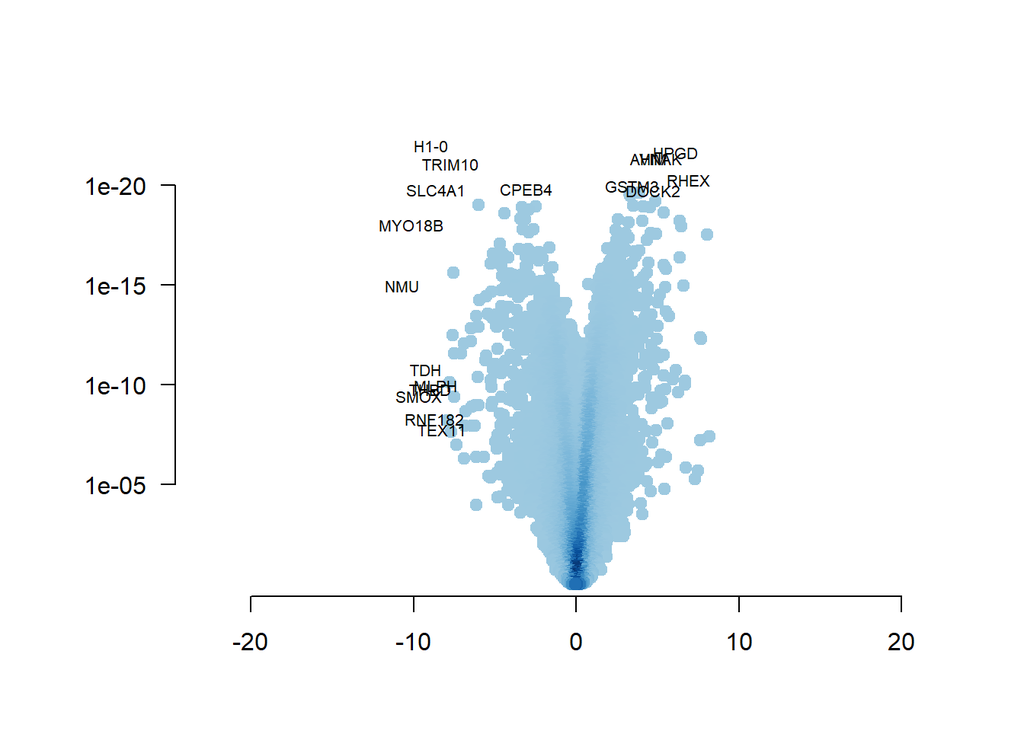

```r
# for sgSCR_pre cell type
volcanoPlot(qlf_output_hits$table$logFC.samples.cell_typesgSCR_pre,
            qlf_output_hits$table$PValue,
            pointLabels = rownames(qlf_output_hits$table))
```

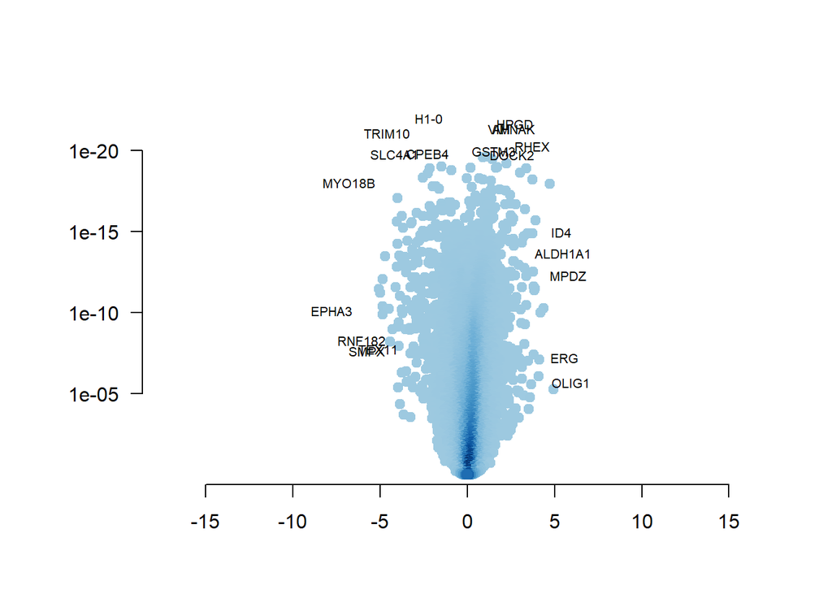

```r
# sgSCR_post cell type
volcanoPlot(qlf_output_hits$table$logFC.samples.cell_typesgSCR_post,
            qlf_output_hits$table$PValue,
            pointLabels = rownames(qlf_output_hits$table))
```

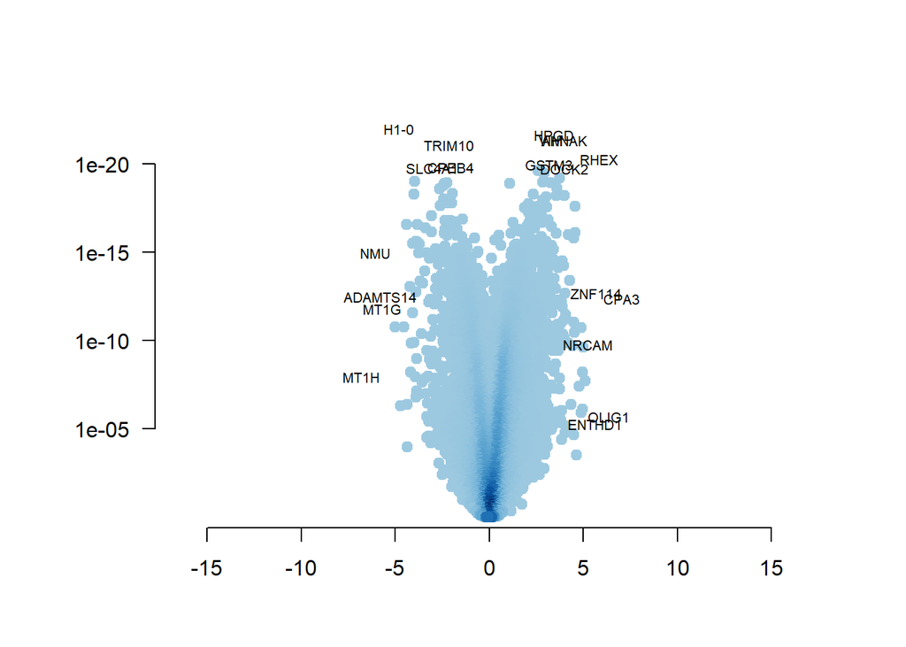

```r
# MBD2KO_pre cell type
volcanoPlot(qlf_output_hits$table$logFC.samples.cell_typeMBD2KO_pre,
            qlf_output_hits$table$PValue,
            pointLabels = rownames(qlf_output_hits$table))
```

## Enrichment Analysis

### Creating thresholded lists of genes

We’re going to create thresholded lists of genes.

```r
#merge gene names with the top hits
ranked_qlf_output_hits <- qlf_output_hits$table
ranked_qlf_output_hits[,
                       c("sgSCR_pre_rank",
                         "sgSCR_post_rank",
                         "MBD2KO_pre_rank")] <- -log(ranked_qlf_output_hits$PValue,base =10) *
  sign(ranked_qlf_output_hits[, c("logFC.samples.cell_typesgSCR_pre",
                                        "logFC.samples.cell_typesgSCR_post",
                                        "logFC.samples.cell_typeMBD2KO_pre")])


sgSCR_pre_qlf_output_hits <- ranked_qlf_output_hits[order(ranked_qlf_output_hits$sgSCR_pre_rank),]
sgSCR_post_qlf_output_hits <- ranked_qlf_output_hits[order(ranked_qlf_output_hits$sgSCR_post_rank),]
MBD2KO_pre_qlf_output_hits <- ranked_qlf_output_hits[order(ranked_qlf_output_hits$MBD2KO_pre_rank),]
```

Save sgSCR_pre upregulated genes and downregulated genes compared to MBD2KO_post cells.

```r
sgSCR_pre_upreg_genes <- rownames(sgSCR_pre_qlf_output_hits)[
  which(sgSCR_pre_qlf_output_hits$PValue < 0.05
        & sgSCR_pre_qlf_output_hits$logFC.samples.cell_typesgSCR_pre > 0)]

sgSCR_pre_upreg<- sgSCR_pre_qlf_output_hits[sgSCR_pre_upreg_genes,
                                            "logFC.samples.cell_typesgSCR_pre"]
names(sgSCR_pre_upreg) <- sgSCR_pre_upreg_genes

sgSCR_pre_downreg_genes <- rownames(sgSCR_pre_qlf_output_hits)[
  which(sgSCR_pre_qlf_output_hits$PValue < 0.05
        & sgSCR_pre_qlf_output_hits$logFC.samples.cell_typesgSCR_pre < 0)]

sgSCR_pre_downreg<- sgSCR_pre_qlf_output_hits[sgSCR_pre_downreg_genes,
                                            "logFC.samples.cell_typesgSCR_pre"]
names(sgSCR_pre_downreg) <- sgSCR_pre_downreg_genes
```

Save sgSCR_post upregulated and downregulated genes compared to the MBD2KO_post cells.

```r
sgSCR_post_upreg_genes <- rownames(sgSCR_post_qlf_output_hits)[
  which(sgSCR_post_qlf_output_hits$PValue < 0.05
        & sgSCR_post_qlf_output_hits$logFC.samples.cell_typesgSCR_post > 0)]

sgSCR_post_upreg<- sgSCR_post_qlf_output_hits[sgSCR_post_upreg_genes,
                                            "logFC.samples.cell_typesgSCR_post"]
names(sgSCR_post_upreg) <- sgSCR_post_upreg_genes

sgSCR_post_downreg_genes <- rownames(sgSCR_post_qlf_output_hits)[
  which(sgSCR_post_qlf_output_hits$PValue < 0.05
        & sgSCR_post_qlf_output_hits$logFC.samples.cell_typesgSCR_post < 0)]

sgSCR_post_downreg<- sgSCR_post_qlf_output_hits[sgSCR_post_downreg_genes,
                                            "logFC.samples.cell_typesgSCR_post"]
names(sgSCR_post_downreg) <- sgSCR_post_downreg_genes
```

Save MBD2KO_pre upregulated genes and downregulated genes compared to the MBC2KO_post cells.

```r
MBD2KO_pre_upreg_genes <- rownames(MBD2KO_pre_qlf_output_hits)[
  which(MBD2KO_pre_qlf_output_hits$PValue < 0.05
        & MBD2KO_pre_qlf_output_hits$logFC.samples.cell_typeMBD2KO_pre > 0)]

MBD2KO_pre_upreg<- MBD2KO_pre_qlf_output_hits[MBD2KO_pre_upreg_genes,
                                            "logFC.samples.cell_typeMBD2KO_pre"]
names(MBD2KO_pre_upreg) <- MBD2KO_pre_upreg_genes

MBD2KO_pre_downreg_genes <- rownames(MBD2KO_pre_qlf_output_hits)[
  which(MBD2KO_pre_qlf_output_hits$PValue < 0.05
        & MBD2KO_pre_qlf_output_hits$logFC.samples.cell_typeMBD2KO_pre < 0)]

MBD2KO_pre_downreg<- MBD2KO_pre_qlf_output_hits[MBD2KO_pre_downreg_genes,
                                            "logFC.samples.cell_typeMBD2KO_pre"]
names(MBD2KO_pre_downreg) <- MBD2KO_pre_downreg_genes
```

Now write the tables in the data folder for later use.

```r
write.table(sgSCR_pre_upreg,
            file=file.path("data","sgSCR_pre_upreg.txt"),sep = "\t",
            row.names = FALSE,col.names = FALSE,quote = FALSE)
write.table(sgSCR_pre_downreg,
            file=file.path("data","sgSCR_pre_downreg.txt"),sep = "\t",
            row.names = FALSE,col.names = FALSE,quote = FALSE)
write.table(sgSCR_post_upreg,
            file=file.path("data","sgSCR_post_upreg.txt"),sep = "\t",
            row.names = FALSE,col.names = FALSE,quote = FALSE)
write.table(sgSCR_post_downreg,
            file=file.path("data","sgSCR_post_downreg.txt"),sep = "\t",
            row.names = FALSE,col.names = FALSE,quote = FALSE)
write.table(MBD2KO_pre_upreg,
            file=file.path("data","MBD2KO_pre_upreg.txt"),sep = "\t",
            row.names = FALSE,col.names = FALSE,quote = FALSE)
write.table(MBD2KO_pre_downreg,
            file=file.path("data","MBD2KO_pre_downreg.txt"),sep = "\t",
            row.names = FALSE,col.names = FALSE,quote = FALSE)
```

### Enrichment Analysis

I chose the GO Biological Process annotation dataset, as I wanted to see how the differentially expressed gene sets contribute to erythroid cell differentiation. I am using the most recent aversion of the dataset available from enrichR, which is GO_Biological_Process_2018.

```r
library(enrichR)
sgSCR_pre_up_enrich <- enrichr(names(sgSCR_pre_upreg), "GO_Biological_Process_2018")
```

```
## Uploading data to Enrichr... Done.
##   Querying GO_Biological_Process_2018... Done.
## Parsing results... Done.
```

```r
sgSCR_pre_down_enrich <- enrichr(names(sgSCR_pre_downreg), "GO_Biological_Process_2018")
```

```
## Uploading data to Enrichr... Done.
##   Querying GO_Biological_Process_2018... Done.
## Parsing results... Done.
```

```r
sgSCR_post_up_enrich <- enrichr(names(sgSCR_post_upreg), "GO_Biological_Process_2018")
```

```
## Uploading data to Enrichr... Done.
##   Querying GO_Biological_Process_2018... Done.
## Parsing results... Done.
```

```r
sgSCR_post_down_enrich <- enrichr(names(sgSCR_post_downreg), "GO_Biological_Process_2018")
```

```
## Uploading data to Enrichr... Done.
##   Querying GO_Biological_Process_2018... Done.
## Parsing results... Done.
```

```r
MBD2KO_pre_up_enrich <- enrichr(names(MBD2KO_pre_upreg), "GO_Biological_Process_2018")
```

```
## Uploading data to Enrichr... Done.
##   Querying GO_Biological_Process_2018... Done.
## Parsing results... Done.
```

```r
MBD2KO_pre_down_enrich <- enrichr(names(MBD2KO_pre_downreg), "GO_Biological_Process_2018")
```

```
## Uploading data to Enrichr... Done.
##   Querying GO_Biological_Process_2018... Done.
## Parsing results... Done.
```

Let’s see the top 15 hits from each enrichment analysis.  
First we will look at the sgSCR_pre and MBD2KO_pre upregulated genes enrichment analysis side by side.

```r
sgSCR_pre_up_enrich_table <- sgSCR_pre_up_enrich$GO_Biological_Process_2018[1:15,
                                                                         c("Term",
                                                                           "Overlap",
                                                                           "Adjusted.P.value")]

MBD2KO_pre_up_enrich_table <- MBD2KO_pre_up_enrich$GO_Biological_Process_2018[1:15,
                                                                         c("Term",
                                                                           "Overlap",
                                                                           "Adjusted.P.value")]

knitr::kable(sgSCR_pre_up_enrich_table,
             "html", align = 'clc', caption = 'Enrichment Analysis of sgSCR_pre Upregulated Genes')
```

Enrichment Analysis of sgSCR_pre Upregulated Genes

| Term | Overlap | Adjusted.P.value |
| --- | --- | --- |
| ribosome biogenesis (GO:0042254) | 152/226 | 0 |
| mitochondrial translation (GO:0032543) | 86/107 | 0 |
| rRNA processing (GO:0006364) | 137/202 | 0 |
| translational termination (GO:0006415) | 77/96 | 0 |
| ncRNA processing (GO:0034470) | 146/227 | 0 |
| mitochondrial translational elongation (GO:0070125) | 71/87 | 0 |
| mitochondrial translational termination (GO:0070126) | 72/89 | 0 |
| gene expression (GO:0010467) | 227/411 | 0 |
| rRNA metabolic process (GO:0016072) | 128/200 | 0 |
| mRNA splicing, via spliceosome (GO:0000398) | 156/261 | 0 |
| translational elongation (GO:0006414) | 77/105 | 0 |
| mRNA processing (GO:0006397) | 163/283 | 0 |
| respiratory electron transport chain (GO:0022904) | 70/94 | 0 |
| RNA metabolic process (GO:0016070) | 119/191 | 0 |
| RNA splicing, via transesterification reactions with bulged adenosine as nucleophile (GO:0000377) | 139/236 | 0 |

```r
knitr::kable(MBD2KO_pre_up_enrich_table,
             "html", align = 'clc', caption = 'Enrichment Analysis of MBD2KO_pre Upregulated Genes')
```

Enrichment Analysis of MBD2KO_pre Upregulated Genes

| Term | Overlap | Adjusted.P.value |
| --- | --- | --- |
| ribosome biogenesis (GO:0042254) | 168/226 | 0 |
| rRNA processing (GO:0006364) | 150/202 | 0 |
| ncRNA processing (GO:0034470) | 161/227 | 0 |
| rRNA metabolic process (GO:0016072) | 142/200 | 0 |
| mitochondrial translation (GO:0032543) | 86/107 | 0 |
| gene expression (GO:0010467) | 231/411 | 0 |
| mitochondrial translational elongation (GO:0070125) | 71/87 | 0 |
| mitochondrial translational termination (GO:0070126) | 72/89 | 0 |
| translational termination (GO:0006415) | 76/96 | 0 |
| translational elongation (GO:0006414) | 79/105 | 0 |
| translation (GO:0006412) | 143/232 | 0 |
| respiratory electron transport chain (GO:0022904) | 72/94 | 0 |
| RNA metabolic process (GO:0016070) | 120/191 | 0 |
| mRNA splicing, via spliceosome (GO:0000398) | 153/261 | 0 |
| mitochondrial ATP synthesis coupled electron transport (GO:0042775) | 65/85 | 0 |

```r
sgSCR_pre_down_enrich_table <- sgSCR_pre_down_enrich$GO_Biological_Process_2018[1:15,
                                                                         c("Term",
                                                                           "Overlap",
                                                                           "Adjusted.P.value")]

MBD2KO_pre_down_enrich_table <- MBD2KO_pre_down_enrich$GO_Biological_Process_2018[1:15,
                                                                         c("Term",
                                                                           "Overlap",
                                                                           "Adjusted.P.value")]


if (!requireNamespace("kableExtra")){
  install.packages("kableExtra")
}

knitr::kable(sgSCR_pre_down_enrich_table,
             "html", align = 'clc', caption = 'Enrichment Analysis of sgSCR_pre Downregulated Genes')
```

Enrichment Analysis of sgSCR_pre Downregulated Genes

| Term | Overlap | Adjusted.P.value |
| --- | --- | --- |
| mitotic cell cycle phase transition (GO:0044772) | 83/221 | 0.0004690 |
| cellular response to nutrient levels (GO:0031669) | 29/54 | 0.0008913 |
| G2/M transition of mitotic cell cycle (GO:0000086) | 52/126 | 0.0014436 |
| cell cycle G2/M phase transition (GO:0044839) | 52/127 | 0.0014447 |
| autophagy of mitochondrion (GO:0000422) | 23/40 | 0.0011780 |
| mitochondrion disassembly (GO:0061726) | 22/38 | 0.0014318 |
| regulation of cell cycle (GO:0051726) | 75/215 | 0.0066333 |
| cellular response to starvation (GO:0009267) | 43/107 | 0.0102943 |
| DNA damage response, signal transduction by p53 class mediator resulting in cell cycle arrest (GO:0006977) | 27/62 | 0.0677395 |
| DNA damage response, signal transduction by p53 class mediator (GO:0030330) | 33/82 | 0.0738940 |
| signal transduction involved in mitotic G1 DNA damage checkpoint (GO:0072431) | 27/63 | 0.0768426 |
| transcription from RNA polymerase II promoter (GO:0006366) | 140/485 | 0.0821044 |
| positive regulation of proteasomal ubiquitin-dependent protein catabolic process (GO:0032436) | 29/70 | 0.0776272 |
| ubiquitin-dependent protein catabolic process (GO:0006511) | 103/341 | 0.0805691 |
| mitotic nuclear division (GO:0140014) | 30/74 | 0.0831949 |

```r
knitr::kable(MBD2KO_pre_down_enrich_table,
             "html", align = 'clc', caption = 'Enrichment Analysis of MBD2KO_pre Downregulated Genes')
```

Enrichment Analysis of MBD2KO_pre Downregulated Genes

| Term | Overlap | Adjusted.P.value |
| --- | --- | --- |
| G2/M transition of mitotic cell cycle (GO:0000086) | 57/126 | 0.0000528 |
| cell cycle G2/M phase transition (GO:0044839) | 57/127 | 0.0000375 |
| mitotic cell cycle phase transition (GO:0044772) | 86/221 | 0.0000336 |
| ciliary basal body-plasma membrane docking (GO:0097711) | 42/96 | 0.0032386 |
| regulation of cell cycle G2/M phase transition (GO:1902749) | 37/84 | 0.0083020 |
| kinetochore organization (GO:0051383) | 10/12 | 0.0111778 |
| autophagy of mitochondrion (GO:0000422) | 21/40 | 0.0224183 |
| sister chromatid segregation (GO:0000819) | 18/32 | 0.0213788 |
| regulation of cell cycle (GO:0051726) | 74/215 | 0.0193644 |
| cellular response to DNA damage stimulus (GO:0006974) | 105/329 | 0.0192022 |
| mitochondrion disassembly (GO:0061726) | 20/38 | 0.0209832 |
| mitotic nuclear division (GO:0140014) | 32/74 | 0.0215673 |
| mitotic sister chromatid segregation (GO:0000070) | 34/82 | 0.0329866 |
| cellular response to nutrient levels (GO:0031669) | 25/54 | 0.0314400 |
| Golgi disassembly (GO:0090166) | 6/6 | 0.0426904 |

8 out of the top 15 biological processes are overlapping. We can see that in both sgSCR_pre and MBD2KO_pre cell types, many biological processes pertaining to the regulation and mechanism of the mitotic cell cycle are downregulated.

Now let’s see the enrichment analyses result of the sgSCR_post cells.

```r
sgSCR_post_up_enrich_table <- sgSCR_post_up_enrich$GO_Biological_Process_2018[1:15,
                                                                         c("Term",
                                                                           "Overlap",
                                                                           "Adjusted.P.value")]

sgSCR_post_down_enrich_table <- sgSCR_post_down_enrich$GO_Biological_Process_2018[1:15,
                                                                         c("Term",
                                                                           "Overlap",
                                                                           "Adjusted.P.value")]

knitr::kable(sgSCR_post_up_enrich_table,
             "html", align = 'clc', caption = 'Enrichment Analysis of sgSCR_post Upregulated Genes')
```

Enrichment Analysis of sgSCR_post Upregulated Genes

| Term | Overlap | Adjusted.P.value |
| --- | --- | --- |
| ribosome biogenesis (GO:0042254) | 153/226 | 0 |
| mRNA splicing, via spliceosome (GO:0000398) | 171/261 | 0 |
| NADH dehydrogenase complex assembly (GO:0010257) | 58/64 | 0 |
| mitochondrial respiratory chain complex I biogenesis (GO:0097031) | 58/64 | 0 |
| mitochondrial respiratory chain complex I assembly (GO:0032981) | 58/64 | 0 |
| mRNA processing (GO:0006397) | 179/283 | 0 |
| mitochondrial ATP synthesis coupled electron transport (GO:0042775) | 70/85 | 0 |
| RNA splicing, via transesterification reactions with bulged adenosine as nucleophile (GO:0000377) | 153/236 | 0 |
| respiratory electron transport chain (GO:0022904) | 75/94 | 0 |
| rRNA processing (GO:0006364) | 133/202 | 0 |
| mitochondrial respiratory chain complex assembly (GO:0033108) | 75/97 | 0 |
| gene expression (GO:0010467) | 234/411 | 0 |
| ncRNA processing (GO:0034470) | 144/227 | 0 |
| RNA metabolic process (GO:0016070) | 124/191 | 0 |
| mitochondrial translation (GO:0032543) | 79/107 | 0 |

```r
knitr::kable(sgSCR_post_down_enrich_table,
             "html", align = 'clc', caption = 'Enrichment Analysis of sgSCR_post Downregulated Genes')
```

Enrichment Analysis of sgSCR_post Downregulated Genes

| Term | Overlap | Adjusted.P.value |
| --- | --- | --- |
| ubiquitin-dependent protein catabolic process (GO:0006511) | 102/341 | 0.0010310 |
| autophagy of mitochondrion (GO:0000422) | 21/40 | 0.0035096 |
| modification-dependent protein catabolic process (GO:0019941) | 50/141 | 0.0023972 |
| protein ubiquitination (GO:0016567) | 136/506 | 0.0025192 |
| mitochondrion disassembly (GO:0061726) | 20/38 | 0.0023787 |
| DNA damage response, signal transduction by p53 class mediator resulting in cell cycle arrest (GO:0006977) | 27/62 | 0.0042197 |
| mitotic chromosome condensation (GO:0007076) | 11/15 | 0.0041783 |
| signal transduction involved in mitotic G1 DNA damage checkpoint (GO:0072431) | 27/63 | 0.0045645 |
| proteasome-mediated ubiquitin-dependent protein catabolic process (GO:0043161) | 84/291 | 0.0060125 |
| DNA damage response, signal transduction by p53 class mediator (GO:0030330) | 32/82 | 0.0058773 |
| positive regulation of cell cycle arrest (GO:0071158) | 32/82 | 0.0053430 |
| mitotic sister chromatid segregation (GO:0000070) | 31/82 | 0.0139219 |
| regulation of autophagy (GO:0010506) | 61/203 | 0.0178910 |
| sister chromatid segregation (GO:0000819) | 16/32 | 0.0200178 |
| protein polyubiquitination (GO:0000209) | 79/283 | 0.0230525 |

### Genes of Interest

Unfortunately, in our dataset, we did not have data for HbF gene. Therefore we will look at its regulators and infer the levels of HbF.

```r
HbF_result <- ranked_qlf_output_hits[which(rownames(ranked_qlf_output_hits) %in% HbF_reg),]

knitr::kable(HbF_result, type = "html", caption = "HbF Regulators")
```

HbF Regulators

|  | logFC.samples.cell_typesgSCR_pre | logFC.samples.cell_typeMBD2KO_pre | logFC.samples.cell_typesgSCR_post | logCPM | F | PValue | FDR | sgSCR_pre_rank | sgSCR_post_rank | MBD2KO_pre_rank |
| --- | --- | --- | --- | --- | --- | --- | --- | --- | --- | --- |
| MYB | 0.7573065 | 0.3788455 | 0.9126870 | 8.606873 | 101.25180 | 0 | 0e+00 | 10.64207 | 10.64207 | 10.64207 |
| BCL11A | -1.0039343 | -0.9193793 | -0.4816175 | 4.957243 | 48.27991 | 0 | 1e-07 | -8.02213 | -8.02213 | -8.02213 |

We can see that in sgSCR_post cells, BCL11A is significantly downregulated compared to MBD2KO_post cells.

## References

[1] Yu, X., Azzo, A., Bilinovich, S. M., Li, X., Dozmorov, M., Kurita, R., Nakamura, Y., Williams, D. C., Ginder, G. D. (2019) Disruption of the MBD2-NuRD Complex But Not MBD3-NuRD Induces High Level HbF Expression in Human Adult Erythroid Cells. Haematologica 104:2361-2371; doi:10.3324/haematol.2018.210963

[2] Davis, S., Meltzer, P. (2007) “GEOquery: a bridge between the Gene Expression Omnibus (GEO) and Bioconductor.” Bioinformatics 14: 1846-1847

[3] Robinson MD, McCarthy DJ and Smyth GK (2010). edgeR: a Bioconductor package for differential expression analysis of digital gene expression data. Bioinformatics 26, 139-140

[4] Durinck, S, Spellman, P. T., Birney, E., Huber, w. (2009) Mapping identifiers for the integration of genomic datasets with the R/Bioconductor package biomaRt. Nature Protocols 4, 1184-1191

[5] Dunrinck, W., Moreau, Y., Kasprzyk, A., Davis, S., Moor, B. D., Brazma, A., Huber, W. (2005) BioMart and Bioconductor: a powerful link between biological databases and microarray data analysis. Bioinformatics 21, 3439-3440

[6] Gu Z, Eils R, Schlesner M (2016). “Complex heatmaps reveal patterns and correlations in multidimensional genomic data.” Bioinformatics.

[7] Gu, Z. (2014) circlize implements and enhances circular visualization in R. Bioinformatics. DOI: 10.1093/bioinformatics/btu393

[8] Ritchie ME, Phipson B, Wu D, Hu Y, Law CW, Shi W, Smyth GK (2015). “limma powers differential expression analyses for RNA-sequencing and microarray studies.” Nucleic Acids Research, 43(7), e47. doi: 10.1093/nar/gkv007.

[9] Kuleshov, M. V., Jones, M. R., Rouillard, A. D., Fernandez, N. F., Duan, Q., Wang, Z., Koplev, S., Jenkins, S. L., Jagodnik, K. M., Lachmann, A., McDermott, M. G., Monteiro, C. D., Gundersen, G. W., & Ma’ayan, A. (2016). Enrichr: a comprehensive gene set enrichment analysis web server 2016 update. Nucleic acids research, 44(W1), W90-W97. https://doi.org/10.1093/nar/gkw377

[10] Zhu, A., Travison, T., Tsai, T., Beasley, W., Xie, Y., Yu, G.C., Laurent, S., Shepherd, R., Sidi, Y., Salzer, B., Gui, G., Fan, Y., Murdoch, D., Zhu, H. (2019) kableExtra: Contruct Complex Table with ‘kable’ and Pipe Syntax.

[11] McCarthy DJ, Chen Y and Smyth GK (2012). Differential expression analysis of multifactor RNA-Seq experiments with respect to biological variation. Nucleic Acids Research 40, 4288-4297

[12] Mello, F.V., Land, M.G.P., Costa, E.S. et al. Maturation-associated gene expression profiles during normal human bone marrow erythropoiesis. Cell Death Discov. 5, 69 (2019). https://doi.org/10.1038/s41420-019-0151-0

[13] Hendrich, B., Guy, J., Ramsahoye, B., Wilson, V. A., & Bird, A. (2001). Closely related proteins MBD2 and MBD3 play distinctive but interacting roles in mouse development. Genes & development, 15(6), 710-723. https://doi.org/10.1101/gad.194101

[14] Ginder, G.D. (2015) Epigenetic regulation of fetal globin gene expression in adult erythroid cells. Translational Research. 165(1):115-125.